# Germany Polling Analysis for Next General Election

## 5.3 SPD’s Neoliberal Shift: A Structural Analysis

```r
spd_shift <- tibble(
  Period   = c("1998–2005 (Schröder / 'Third Way')",
                "2005–2013 (GroKo junior partner)",
                "2013–2021 (GroKo, then Ampel preparation)",
                "2021–2024 (Ampel / traffic-light coalition)",
                "2025– (GroKo junior partner under Merz CDU)"),
  Economic_stance = c(
    "Hartz I–IV welfare reforms: compulsory job schemes, benefit cuts. Germany's version of Blair-era 'progressive neoliberalism'.",
    "Junior partner to CDU; no reversal of Hartz reforms; minimum wage introduced in 2015 as partial concession.",
    "SPD began re-emphasising redistribution; Bürgergeld (citizen's income) eventually rebranded Hartz 4.",
    "Coalition with Greens + FDP forced fiscal conservatism (debt brake); SPD failed to push social agenda against FDP veto.",
    "Coalition contract includes €15/hr minimum wage, but SPD is now junior partner in CDU-led government; fiscal agenda set by Merz."
  ),
  Electoral_impact = c(
    "Haemorrhage of blue-collar vote; Die Linke founded 2007 explicitly as an SPD splinter by those abandoned by Hartz.",
    "SPD stabilised at ~25%; never recovered its pre-Schröder base.",
    "Brief recovery to 25.7% in 2021 via Scholz 'competence' brand; did not translate into lasting structural gain.",
    "Coalition seen as failure; SPD fell to 16.4% as largest losses went to CDU (right) and Die Linke/BSW (left).",
    "No recovery path visible; SPD locked into governing with CDU, unable to differentiate or oppose."
  )
)

spd_shift %>%
  kable(
    caption = "SPD Economic Policy Trajectory and Electoral Consequences",
    col.names = c("Period", "Economic Policy Stance", "Electoral Impact"),
    align = "lll"
  ) %>%
  kable_styling(bootstrap_options = c("striped", "hover"), full_width = TRUE) %>%
  column_spec(1, bold = TRUE, width = "18%") %>%
  column_spec(2, width = "42%") %>%
  column_spec(3, width = "40%", italic = TRUE)
```

SPD Economic Policy Trajectory and Electoral Consequences

| Period | Economic Policy Stance | Electoral Impact |
| --- | --- | --- |
| 1998–2005 (Schröder / ‘Third Way’) | Hartz I–IV welfare reforms: compulsory job schemes, benefit cuts. Germany’s version of Blair-era ‘progressive neoliberalism’. | Haemorrhage of blue-collar vote; Die Linke founded 2007 explicitly as an SPD splinter by those abandoned by Hartz. |
| 2005–2013 (GroKo junior partner) | Junior partner to CDU; no reversal of Hartz reforms; minimum wage introduced in 2015 as partial concession. | SPD stabilised at ~25%; never recovered its pre-Schröder base. |
| 2013–2021 (GroKo, then Ampel preparation) | SPD began re-emphasising redistribution; Bürgergeld (citizen’s income) eventually rebranded Hartz 4. | Brief recovery to 25.7% in 2021 via Scholz ‘competence’ brand; did not translate into lasting structural gain. |
| 2021–2024 (Ampel / traffic-light coalition) | Coalition with Greens + FDP forced fiscal conservatism (debt brake); SPD failed to push social agenda against FDP veto. | Coalition seen as failure; SPD fell to 16.4% as largest losses went to CDU (right) and Die Linke/BSW (left). |
| 2025– (GroKo junior partner under Merz CDU) | Coalition contract includes €15/hr minimum wage, but SPD is now junior partner in CDU-led government; fiscal agenda set by Merz. | No recovery path visible; SPD locked into governing with CDU, unable to differentiate or oppose. |

# 6 Die Linke & Grüne: Can the Left Bypass the SPD?

## 6.1 The Convergence

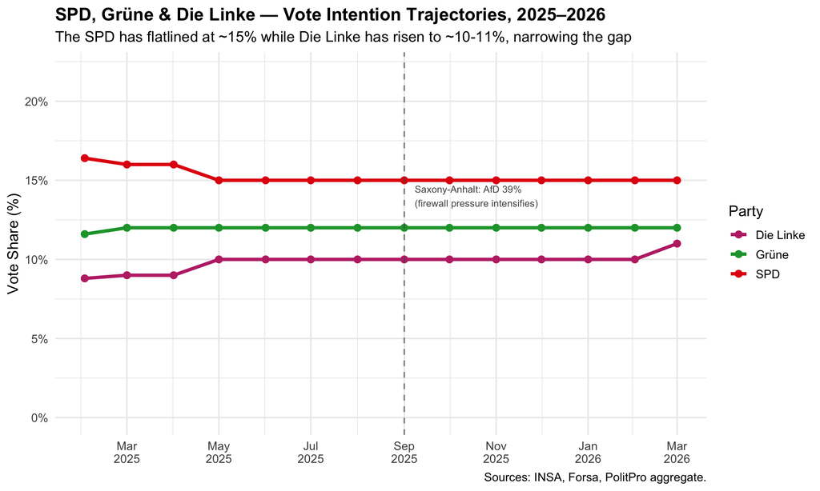

```r
left_trend <- polls_de %>%
  select(date, SPD, Gruene, Linke) %>%
  rename(Grüne = Gruene, `Die Linke` = Linke) %>%
  pivot_longer(cols = c(SPD, Grüne, `Die Linke`),
               names_to = "Party", values_to = "Share")

p_left <- left_trend %>%
  ggplot(aes(x = date, y = Share, colour = Party)) +
  geom_line(linewidth = 1.4) +
  geom_point(size = 2.5) +
  # Mark crossover risk
  geom_vline(xintercept = as.numeric(as.Date("2025-09-01")),
             linetype = "dashed", colour = "#555555", alpha = 0.7) +
  annotate("text", x = as.Date("2025-09-08"), y = 14,
           label = "Saxony-Anhalt: AfD 39%\n(firewall pressure intensifies)",
           size = 3, hjust = 0, colour = "#555555") +
  scale_colour_manual(values = c(
    "SPD"       = "#E3000F",
    "Grüne"     = "#1AA037",
    "Die Linke" = "#BE3075"
  )) +
  scale_y_continuous(labels = label_percent(scale = 1), limits = c(0, 22)) +
  scale_x_date(date_breaks = "2 months", date_labels = "%b\n%Y") +
  labs(
    title    = "SPD, Grüne & Die Linke — Vote Intention Trajectories, 2025–2026",
    subtitle = "The SPD has flatlined at ~15% while Die Linke has risen to ~10-11%, narrowing the gap",
    x        = NULL, y = "Vote Share (%)", colour = "Party",
    caption  = "Sources: INSA, Forsa, PolitPro aggregate."
  ) +
  theme_minimal(base_size = 13) +
  theme(plot.title = element_text(face = "bold"), legend.position = "right")

print(p_left)
```

## 6.2 Die Linke’s Opportunity

```r
linke_factors <- tibble(
  Direction  = c("For", "For", "For", "For",
                  "Unclear", "Against", "Against"),
  Factor     = c(
    "Viral moment: Heidi Reichinnek's Bundestag speech against Merz-AfD cooperation (25m+ views)",
    "Membership boom during 2025 campaign; party attracting young anti-fascist voters",
    "Won 6 direct mandates in 2025 (4 in Berlin) — geographic strongholds emerging",
    "Uniquely positioned as the only party that will never cooperate with CDU or AfD — a clear differentiator",
    "BSW split: shed pro-Russia, socially conservative 'left in name only' voters; but also lost ~350k genuine supporters who may not return",
    "Eastern strongholds overlap with AfD-dominated territory — hard to organise",
    "Coalition prospects: if they join a CDU-led coalition they lose their identity; if they refuse they may be irrelevant in government"
  ),
  Importance = c(
    "Very high — a defining cultural moment that gave Die Linke a new generation of voters",
    "High — membership correlates with canvassing, fundraising and local councillor pipeline",
    "High — direct mandates provide proportional representation even if they fall below 5%",
    "High — the SPD is *in* the CDU-led GroKo, making Die Linke the largest left opposition. The Grüne are in opposition, but as a broadly pro-system party have less appetite for confrontation than Die Linke.",
    "The split has two readings. Positive: freed from the Wagenknecht wing's cultural conservatism and pro-Russia positioning, Die Linke can openly court SPD refugees and young progressives previously deterred — and the post-split polling trajectory (rising membership, higher floor) lends weight to this. Negative: the ~350k BSW voters represent a distinct electorate unlikely to return, and BSW's continued presence fractures the broader left vote even in failure.",
    "Moderate — party is weak in rural east despite ostensibly being the party for eastern workers",
    "Critical — the same governing dilemma that destroyed the SPD. How Die Linke handles it will define the next decade."
  )
)

linke_factors %>%
  kable(
    caption = "Die Linke: Key Factors in Challenging SPD as Germany's Primary Left Party",
    col.names = c("Direction", "Factor", "Why It Matters"),
    align = "lll"
  ) %>%
  kable_styling(bootstrap_options = c("striped", "hover"), full_width = TRUE) %>%
  column_spec(1, bold = TRUE, width = "8%",
              color = "white",
              background = case_when(
                linke_factors$Direction == "For"     ~ "#02A95B",
                linke_factors$Direction == "Against"  ~ "#cc3333",
                TRUE                                  ~ "#888888")) %>%
  column_spec(2, width = "42%") %>%
  column_spec(3, width = "50%", italic = TRUE)
```

Die Linke: Key Factors in Challenging SPD as Germany’s Primary Left Party

[output not shown]

## 6.3 Grüne vs Die Linke: Are They Competing?

```r
# Policy position comparison
policy_comparison <- tibble(
  Issue = c("Climate/environment", "Immigration/refugees", "NATO/military",
             "Redistribution/wealth tax", "Housing/rent control",
             "Anti-fascism / anti-AfD", "EU integration", "Coalition flexibility"),
  Gruene_pos    = c("Core identity; strong support", "Pro-open borders; humanitarian",
                     "Pro-NATO; supported Zeitenwende rearmament",
                     "Moderate redistribution; market-friendly on industrial policy",
                     "Some rent controls; pro-construction",
                     "Strong formally; cooperated with CDU in federal coalition",
                     "Strongly pro-EU", "Very high — governs with CDU or SPD"),
  Linke_pos     = c("Strong support but secondary to social justice",
                     "Pro-open borders; anti-deportation",
                     "Anti-NATO; opposes rearmament and weapons to Ukraine",
                     "Strong redistribution; wealth tax; anti-privatisation",
                     "Strong rent control; socialisation of housing",
                     "Core identity; explicitly refuses all cooperation with CDU/AfD",
                     "Pro-EU but critical of austerity rules",
                     "Very low — refuses coalition with CDU or right-leaning parties"),
  Key_tension   = c("Grüne more technocratic; Linke more redistributive",
                     "Both similar — but Linke more explicitly anti-deportation",
                     "MAJOR DIVIDE — Grüne supports Zeitenwende; Linke opposes",
                     "Linke more aggressive on wealth/tax; Grüne more business-compatible",
                     "Both support; Linke more radical",
                     "Grüne credibility weakened by governing with CDU",
                     "Similar",
                     "Linke's refusal to govern with CDU may be its biggest electoral asset")
)

policy_comparison %>%
  kable(
    caption = "Grüne vs Die Linke: Policy Positions and Key Divergences",
    col.names = c("Issue", "Grüne Position", "Die Linke Position", "Key Tension"),
    align = "llll"
  ) %>%
  kable_styling(bootstrap_options = c("striped", "hover"), full_width = TRUE) %>%
  column_spec(1, bold = TRUE, width = "12%") %>%
  column_spec(2, width = "28%") %>%
  column_spec(3, width = "28%") %>%
  column_spec(4, width = "32%", italic = TRUE)
```

Grüne vs Die Linke: Policy Positions and Key Divergences

| Issue | Grüne Position | Die Linke Position | Key Tension |
| --- | --- | --- | --- |
| Climate/environment | Core identity; strong support | Strong support but secondary to social justice | Grüne more technocratic; Linke more redistributive |
| Immigration/refugees | Pro-open borders; humanitarian | Pro-open borders; anti-deportation | Both similar — but Linke more explicitly anti-deportation |
| NATO/military | Pro-NATO; supported Zeitenwende rearmament | Anti-NATO; opposes rearmament and weapons to Ukraine | MAJOR DIVIDE — Grüne supports Zeitenwende; Linke opposes |
| Redistribution/wealth tax | Moderate redistribution; market-friendly on industrial policy | Strong redistribution; wealth tax; anti-privatisation | Linke more aggressive on wealth/tax; Grüne more business-compatible |
| Housing/rent control | Some rent controls; pro-construction | Strong rent control; socialisation of housing | Both support; Linke more radical |
| Anti-fascism / anti-AfD | Strong formally; cooperated with CDU in federal coalition | Core identity; explicitly refuses all cooperation with CDU/AfD | Grüne credibility weakened by governing with CDU |
| EU integration | Strongly pro-EU | Pro-EU but critical of austerity rules | Similar |
| Coalition flexibility | Very high — governs with CDU or SPD | Very low — refuses coalition with CDU or right-leaning parties | Linke’s refusal to govern with CDU may be its biggest electoral asset |

The critical structural observation is that the Grüne and Die Linke **are not in direct competition** for the same voter pool. The Greens attract urban, university-educated, post-materialist voters for whom climate and social liberalism are primary; Die Linke attracts economically precarious voters, eastern workers, young anti-fascist voters, and those for whom redistribution and anti-militarism are primary. Their overlap exists — both parties appeal to young progressives — but they are ultimately competing for different segments of a broader left-of-centre electorate. The more urgent question is whether either, together, can replace the SPD as the second anchor of the German left alongside the Greens.

# 7 Historical Precedents for German Party Fragmentation

### 7.0.1 The Weimar Warning

```r
weimar_data <- tibble(
  Party   = c("NSDAP", "SPD", "KPD", "Centre", "DNVP", "Other", "Staatspartei"),
  Votes   = c(37.4, 21.6, 14.6, 11.9, 5.9, 5.6, 1.0),
  Year    = rep("1932 (Jul)", 7),
  Modern_note = c("AfD analogue (populist far-right, anti-system)",
                   "SPD (social democrats, collapsing under pressure)",
                   "Die Linke (radical left, anti-establishment)",
                   "CDU/CSU (Christian centre-right)",
                   "Conservative nationalist splinter",
                   "Various regional/special interest",
                   "Liberal democrats (like FDP)")
)

# Note: this is NOT to equate AfD = NSDAP — the note column clarifies
weimar_data %>%
  kable(
    caption = "July 1932 Reichstag Election — For Structural Comparison Only (NOT an equivalence claim)",
    col.names = c("Party", "Vote %", "Year", "Structural analogue today"),
    align = "lrll"
  ) %>%
  kable_styling(bootstrap_options = c("striped", "hover", "condensed"),
                full_width = FALSE) %>%
  footnote(
    general = "IMPORTANT: This table is presented for structural comparison of fragmentation patterns only.
    The AfD is NOT the NSDAP, and current German democracy has robust constitutional safeguards that did not exist in 1932.
    The comparison is to illustrate how fragmented electorates under economic stress can produce
    anti-system surges — and the lesson that cordon sanitaire policies must be maintained rigorously.
    The 5% threshold itself was introduced in 1949 precisely to prevent Weimar-style fragmentation.",
    general_title = "CAUTION: "
  )
```

July 1932 Reichstag Election — For Structural Comparison Only (NOT an equivalence claim)

| Party | Vote % | Year | Structural analogue today |
| --- | --- | --- | --- |
| NSDAP | 37.4 | 1932 (Jul) | AfD analogue (populist far-right, anti-system) |
| SPD | 21.6 | 1932 (Jul) | SPD (social democrats, collapsing under pressure) |
| KPD | 14.6 | 1932 (Jul) | Die Linke (radical left, anti-establishment) |
| Centre | 11.9 | 1932 (Jul) | CDU/CSU (Christian centre-right) |
| DNVP | 5.9 | 1932 (Jul) | Conservative nationalist splinter |
| Other | 5.6 | 1932 (Jul) | Various regional/special interest |
| Staatspartei | 1.0 | 1932 (Jul) | Liberal democrats (like FDP) |

CAUTION:  
IMPORTANT: This table is presented for structural comparison of fragmentation patterns only. The AfD is NOT the NSDAP, and current German democracy has robust constitutional safeguards that did not exist in 1932. The comparison is to illustrate how fragmented electorates under economic stress can produce anti-system surges — and the lesson that cordon sanitaire policies must be maintained rigorously. The 5% threshold itself was introduced in 1949 precisely to prevent Weimar-style fragmentation.

### 7.0.2 What Made 1932 Structurally Distinctive — and What It Signals for 2029

The July 1932 election is analytically significant not merely because of the NSDAP’s 37.4% result, but because of the **collapse of the political centre** under the pressure of Weimar’s economic crisis. The SPD — like its modern counterpart — was haemorrhaging support in every direction: to the KPD on the radical left, and to the NSDAP from working-class voters who felt abandoned. The Centre Party and DNVP were locked in a defensive crouch. Crucially, **no majority coalition was possible that excluded the largest anti-system party** — producing the governance paralysis that ultimately allowed Hitler’s appointment as Chancellor.

The 2029 parallel is not equivalent, but it is structurally instructive. Consider a specific high-pressure scenario: the Kenya coalition (CDU/CSU + SPD + Grüne) is formed after the 2029 election to exclude the AfD, but **breaks down mid-term** — whether over fiscal policy, migration, or climate investment. The structural consequences of such a collapse would likely mirror 1932’s dynamic in one key respect: **the parties associated with failed governance suffer punishing vote losses, while anti-system parties and genuine opposition parties gain**.

```r
# Post-Kenya coalition collapse scenario — projecting vote-share shifts
# Assumption: Kenya coalition (CDU/CSU + SPD + Grüne) fails in ~2031, leading to snap election
# All three governing parties punished. Only Die Linke and AfD gain — the two parties
# entirely outside the coalition and untouched by its failure.

kenya_collapse <- tibble(
  Party         = c("CDU/CSU", "AfD", "SPD", "Grüne", "Die Linke", "BSW", "FDP"),
  Kenya_entry   = c(24, 25, 13, 13, 11, 4, 3),
  Post_collapse = c(20, 31,  9,  9, 16, 5, 3),
  Change        = c(-4, +6, -4, -4, +5, +1, 0),
  Direction     = c("Loss", "Gain", "Loss", "Loss", "Gain", "Gain", "Unchanged")
)

kenya_collapse %>%
  mutate(Change_fmt = ifelse(Change > 0, paste0("+", Change, "pp"), paste0(Change, "pp"))) %>%
  select(Party, Kenya_entry, Post_collapse, Change_fmt, Direction) %>%
  kable(
    caption = "Projected Vote-Share Shifts: Kenya Coalition Entry vs Post-Collapse Snap Election",
    col.names = c("Party", "At Kenya entry (%)", "Post-collapse (%)", "Change", "Direction"),
    align = "lrrll"
  ) %>%
  kable_styling(bootstrap_options = c("striped", "hover", "condensed"), full_width = FALSE) %>%
  row_spec(which(kenya_collapse$Party == "AfD"),     bold = TRUE, color = "white", background = "#009EE0") %>%
  row_spec(which(kenya_collapse$Party == "CDU/CSU"), bold = TRUE, color = "white", background = "#000000") %>%
  row_spec(which(kenya_collapse$Party == "SPD"),     bold = TRUE, color = "white", background = "#E3000F") %>%
  row_spec(which(kenya_collapse$Party == "Grüne"),   bold = TRUE, color = "white", background = "#1AA037") %>%
  row_spec(which(kenya_collapse$Party == "Die Linke"), bold = TRUE, color = "white", background = "#BE3075") %>%
  footnote(
    general = "Scenario: Kenya coalition (CDU/CSU + SPD + Grüne) formed in 2029, collapses mid-term (~2031).
    All three governing parties are punished — CDU/CSU for presiding over continued stagnation,
    SPD for a second consecutive GroKo-style capitulation, and Grüne for compromising their
    climate agenda to hold the coalition together. Only Die Linke (the KPD structural analogue —
    consistent opposition, untouched by coalition failure) and the AfD gain substantially.
    This is the core 1932 lesson: failed broad coalitions do not neutralise anti-system parties;
    they feed them. CAUTION: Illustrative projections only, not predictions.",
    general_title = "Note: "
  )
```

Projected Vote-Share Shifts: Kenya Coalition Entry vs Post-Collapse Snap Election

| Party | At Kenya entry (%) | Post-collapse (%) | Change | Direction |
| --- | --- | --- | --- | --- |
| CDU/CSU | 24 | 20 | -4pp | Loss |
| AfD | 25 | 31 | +6pp | Gain |
| SPD | 13 | 9 | -4pp | Loss |
| Grüne | 13 | 9 | -4pp | Loss |
| Die Linke | 11 | 16 | +5pp | Gain |
| BSW | 4 | 5 | +1pp | Gain |
| FDP | 3 | 3 | 0pp | Unchanged |

Note:  
Scenario: Kenya coalition (CDU/CSU + SPD + Grüne) formed in 2029, collapses mid-term (~2031). All three governing parties are punished — CDU/CSU for presiding over continued stagnation, SPD for a second consecutive GroKo-style capitulation, and Grüne for compromising their climate agenda to hold the coalition together. Only Die Linke (the KPD structural analogue — consistent opposition, untouched by coalition failure) and the AfD gain substantially. This is the core 1932 lesson: failed broad coalitions do not neutralise anti-system parties; they feed them. CAUTION: Illustrative projections only, not predictions.

### 7.0.3 Post-War Fragmentation Patterns

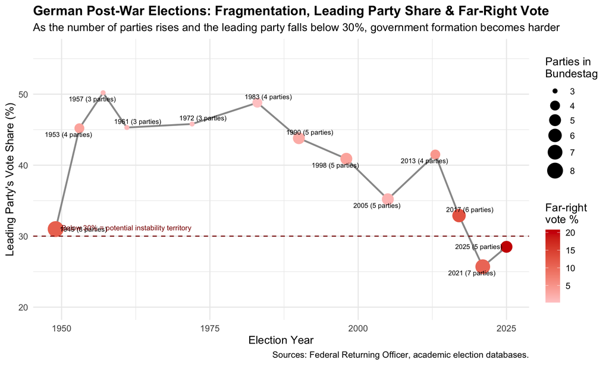

```r
postwar <- tibble(
  Year    = c(1949, 1953, 1957, 1961, 1972, 1983, 1990, 1998, 2005, 2013, 2017, 2021, 2025),
  Parties = c(8, 4, 3, 3, 3, 4, 5, 5, 5, 4, 6, 7, 5),
  # Combined far-right vote share (excl. CDU/CSU itself)
  Farright = c(11.1, 3.3, 1.0, 0.8, 0.3, 0.2, 2.4, 3.3, 1.6, 4.7, 12.6, 10.4, 20.8),
  Max_share = c(31.0, 45.2, 50.2, 45.3, 45.8, 48.8, 43.8, 40.9, 35.2, 41.5, 32.9, 25.7, 28.5)
)

p_pw <- postwar %>%
  ggplot(aes(x = Year, y = Max_share)) +
  geom_line(colour = "grey60", linewidth = 1) +
  geom_point(aes(colour = Farright, size = Parties)) +
  geom_text_repel(aes(label = paste0(Year, " (", Parties, " parties)")),
                  size = 2.8, max.overlaps = 12) +
  scale_colour_gradient(low = "#FFCCCC", high = "#cc0000", name = "Far-right\nvote %") +
  scale_size_continuous(range = c(2, 8), name = "Parties in\nBundestag") +
  geom_hline(yintercept = 30, linetype = "dashed", colour = "darkred") +
  annotate("text", x = 1950, y = 31.2,
           label = "Below 30% = potential instability territory",
           colour = "darkred", size = 3, hjust = 0) +
  scale_y_continuous(limits = c(20, 56)) +
  labs(
    title    = "German Post-War Elections: Fragmentation, Leading Party Share & Far-Right Vote",
    subtitle = "As the number of parties rises and the leading party falls below 30%, government formation becomes harder",
    x        = "Election Year", y = "Leading Party's Vote Share (%)",
    caption  = "Sources: Federal Returning Officer, academic election databases."
  ) +
  theme_minimal(base_size = 13) +
  theme(plot.title = element_text(face = "bold"), legend.position = "right")

print(p_pw)
```

# 8 Coalition Arithmetic & Scenarios to 2029

## 8.1 Current Bundestag (2025) Coalition Options

```r
coalitions_de <- tibble(
  Coalition = c(
    "CDU/CSU + SPD (Grand Coalition — current government)",
    "CDU/CSU + SPD + Grüne (Kenya coalition — theoretical)",
    "CDU/CSU + AfD (Bahamas coalition)",
    "SPD + Grüne + Die Linke (Red-Red-Green)",
    "CDU/CSU alone (minority government)"
  ),
  Seats_2025 = c("208 + 121 = 329", "208 + 121 + 85 = 414", "208 + 151 = 359",
                  "121 + 85 + 64 = 270", "208"),
  Majority   = c("Yes (329 > 316)", "Yes (comfortable)", "Yes — but Brandmauer prohibits",
                  "No (270 < 316)", "No (208 < 316)"),
  Status     = c("In government as of Apr 2025", "Not formed — possible theoretically",
                  "Refused — CDU maintains Brandmauer at federal level",
                  "SPD is in GroKo — not available. Grüne are in opposition but will not join a left-only bloc without SPD anchor.",
                  "Impossible without external support")
)

coalitions_de %>%
  kable(
    caption = "2025 Bundestag: Coalition Arithmetic and Feasibility",
    col.names = c("Coalition", "Combined Seats", "Majority?", "Status"),
    align = "llll"
  ) %>%
  kable_styling(bootstrap_options = c("striped", "hover"), full_width = TRUE) %>%
  column_spec(1, bold = TRUE, width = "28%") %>%
  column_spec(2, width = "22%") %>%
  column_spec(3, width = "18%") %>%
  column_spec(4, width = "32%", italic = TRUE) %>%
  row_spec(1, background = "#E8F4E8") %>%
  row_spec(3, background = "#FFE8E8")
```

2025 Bundestag: Coalition Arithmetic and Feasibility

| Coalition | Combined Seats | Majority? | Status |
| --- | --- | --- | --- |
| CDU/CSU + SPD (Grand Coalition — current government) | 208 + 121 = 329 | Yes (329 > 316) | In government as of Apr 2025 |
| CDU/CSU + SPD + Grüne (Kenya coalition — theoretical) | 208 + 121 + 85 = 414 | Yes (comfortable) | Not formed — possible theoretically |
| CDU/CSU + AfD (Bahamas coalition) | 208 + 151 = 359 | Yes — but Brandmauer prohibits | Refused — CDU maintains Brandmauer at federal level |
| SPD + Grüne + Die Linke (Red-Red-Green) | 121 + 85 + 64 = 270 | No (270 < 316) | SPD is in GroKo — not available. Grüne are in opposition but will not join a left-only bloc without SPD anchor. |
| CDU/CSU alone (minority government) | 208 | No (208 < 316) | Impossible without external support |

## 8.2 2029 Scenarios

```r
scenarios_2029_table <- tibble(
  Scenario   = c(
    "A: AfD surges (30%)",
    "A: AfD surges (30%)",
    "B: AfD holds (25%), left gains",
    "B: AfD holds (25%), left gains",
    "C: AfD fades (20%), CDU recovers"
  ),
  Coalition  = c(
    "CDU/CSU + SPD (GroKo) — impossible; 154+77=231, well short of 316",
    "CDU/CSU + SPD + Grüne (Kenya coalition) — required for comfortable majority",
    "CDU/CSU + SPD GroKo — impossible; 170+92=262, short of 316",
    "CDU/CSU alone may need Grüne support",
    "CDU/CSU + SPD GroKo — still short; 196+91=287; Kenya (196+91+105=392) or CDU+Linke needed"
  ),
  Combined_seats = c(
    "154+77 = 231 — well short; Kenya (154+77+98=329) needed",
    "350+ — comfortable",
    "170+92 = 262 — short; Kenya (170+92+99=361) required",
    "Multiple options",
    "196+91 = 287 — still short; Kenya (196+91+105=392) comfortable"
  ),
  Likelihood = c(
    "Possible if economic stagnation continues and CDU seen as failed incumbent",
    "Most likely outcome in Scenario A — Merz would resist but may have no choice",
    "Baseline; AfD at current polling trajectory; CDU weakened by GroKo incumbency",
    "If GroKo fails visibly, CDU may need Kenya or early election",
    "Requires CDU to successfully claim credit for economic improvement — uncertain"
  )
)

scenarios_2029_table %>%
  kable(
    caption = "Plausible Coalition Scenarios by 2029",
    col.names = c("Scenario", "Coalition / Arrangement", "Combined Seats", "Feasibility"),
    align = "llll"
  ) %>%
  kable_styling(bootstrap_options = c("striped", "hover"), full_width = TRUE) %>%
  column_spec(1, bold = TRUE, width = "16%") %>%
  column_spec(2, width = "30%") %>%
  column_spec(3, width = "22%") %>%
  column_spec(4, width = "32%", italic = TRUE) %>%
  collapse_rows(columns = 1, valign = "top")
```

Plausible Coalition Scenarios by 2029

[output not shown]

## 8.3 Most Likely Trajectory to 2029

The post-2025 dynamics point toward a slow-burn political crisis rather than a sudden rupture. The most probable path looks as follows.

**The Brandmauer pressure point** is September 2026. Saxony-Anhalt votes with the AfD at 39% in current polling — more than 10 points ahead of the CDU. If the firewall holds and a messy CDU-SPD-Die Linke or CDU-Die Linke arrangement is cobbled together, the AfD will claim democratic exclusion loudly and probably gain votes from it. If a CDU minority government in Saxony-Anhalt accepts AfD legislative support case-by-case, it will be described as a formal breach of the firewall — with severe implications for the federal level.

**Die Linke and the Greens** are not structurally positioned to *replace* the SPD but are positioned to *split* its old electorate permanently. Die Linke at 10–11% in current polls, sustained by its role as the only genuine parliamentary opposition, represents a higher floor than the party has had since 2013. The Greens at 12% have stabilised after their Ampel losses. Together, a theoretical left bloc (SPD + Grüne + Die Linke) holds approximately 38% — not enough to govern without the CDU’s participation, but enough to deny the right-AfD bloc a majority.

# 9 Key Findings & Analysis

```r
findings_de <- tibble(
  Theme = c(
    "AfD Trajectory",
    "Brandmauer Integrity",
    "SPD Structural Decline",
    "Die Linke Opportunity",
    "Coalition Arithmetic",
    "East-West Divide",
    "Historical Parallel"
  ),
  `Current Status` = c(
    "AfD at ~25% nationally (Mar 2026); doubled from 2021; leads CDU in multiple polls for first time",
    "Holds federally on coalitions; BREACHED on Jan 29 2025 (indirect vote cooperation); eroded at municipal level",
    "SPD at 15% now; modelled at 11–13% by 2029 after GroKo incumbency drag — consistent with every previous junior-partner punishment cycle",
    "Die Linke at 10–11%; strongest since pre-BSW split; membership boom; Reichinnek viral moment",
    "CDU/CSU + SPD GroKo holds 329/630 today but is projected to fall to 231–287 by 2029 across all scenarios — Kenya coalition likely required in every case",
    "AfD dominates all 5 former East German states; Saxony-Anhalt AfD at 39% (Sep 2025 poll); firewall at breaking point in east",
    "Post-war fragmentation record: 7 parties in 2021 reduced to 5 in 2025; but AfD at 20.8% is highest far-right share since Nazi era"
  ),
  `Key Implication` = c(
    "AfD has passed the 'protest party' threshold — it is now a structural force with a durable social coalition",
    "Municipal erosion + 2025 federal breach set a precedent; Saxony-Anhalt 2026 will test the federal level",
    "Every GroKo punishes the junior partner; SPD projected at 11–13% by 2029, likely ceding second-left position to Die Linke",
    "Unique positioning as only opposition party; refuses CDU/AfD cooperation; captures anti-establishment left",
    "AfD cannot force a hung parliament under PR, but can force increasingly uncomfortable coalition maths for CDU",
    "East German state elections 2026 are the critical near-term tests; if CDU accepts AfD support, firewall collapses nationally",
    "5% threshold has prevented Weimar-style fragmentation but does not prevent sustained far-right consolidation above it"
  )
)

findings_de %>%
  kable(caption = "Summary of Key Analytical Findings — Germany 2025–2026",
        align = "lll") %>%
  kable_styling(bootstrap_options = c("striped", "hover"), full_width = TRUE) %>%
  column_spec(1, bold = TRUE, width = "14%") %>%
  column_spec(2, width = "43%") %>%
  column_spec(3, width = "43%", italic = TRUE)
```

Summary of Key Analytical Findings — Germany 2025–2026

[output not shown]

# 10 Methodology & Data Notes

[output not shown]

*Analysis produced in R Markdown. Post-election polling from INSA, Forsa, Infratest dimap, Forschungsgruppe Wahlen, and PolitPro aggregate. 2025 federal election data from the Federal Returning Officer. Voter migration from Infratest dimap exit poll. Brandmauer analysis from WZB Berlin (2025 empirical study). All projections are model estimates, not predictions.*